For this homework, Bullion Gold Selling Price (TRY/Gr),(USD) US Dollar (Selling), and Domestic Debt Position (Treasury)(TRY Thousand)(Monthly) data were retrieved from [Central Bank of the Republic of Turkey (CBRT)](https://evds2.tcmb.gov.tr) and three search cases corresponding these data sets were retrieved by using Google Trends. After having received these, ultimate aim is to evaluate both google trends data and Central Bank data both by individually, dual matchings and altogether and then come up with an analysis of their relationships: distributions, trends, correlation.

Following code is to install and call relevant packages to perform analysis well by using visualization tools. gold_usd_debt data was extracted from TCMB and only relevant rows were used. Tarih coloumn was transformed as year format to perform the code and other coloumns related to gold and USD exchange rate were formatted as numeric rather than char. Output of this code is the main attributes of the data and used to check its validity to run the code in a correct way.

```r
#install.packages("readxl")
#install.packages("lubridate")
#install.packages("zoo")
library(readxl)
library(lubridate)
library(zoo)
```

```r
library(ggplot2)

gold_usd_debt <- read_excel("/Users/ertugruluyar/Downloads/gold-usd-debt.xlsx")
gold_usd_debt <- gold_usd_debt[1:59,]
gold_usd_debt$Tarih <- as.yearmon(gold_usd_debt$Tarih)
gold_usd_debt$`TP MK KUL YTL` <- as.numeric(gold_usd_debt$`TP MK KUL YTL`)
gold_usd_debt$`TP DK USD S YTL` <- as.numeric(gold_usd_debt$`TP DK USD S YTL`)
str(gold_usd_debt)
```

```
## tbl_df [59 × 4] (S3: tbl_df/tbl/data.frame)
##  $ Tarih          : 'yearmon' num [1:59] Apr 2017 May 2017 Jun 2017 Jul 2017 ...
##  $ TP MK KUL YTL  : num [1:59] 150 143 143 142 145 ...
##  $ TP DK USD S YTL: num [1:59] 3.66 3.57 3.53 3.57 3.52 ...
##  $ TP KB A09      : num [1:59] 4.87e+08 4.90e+08 4.95e+08 5.05e+08 5.13e+08 ...
```

```r
gold_usd_debt$Year <- factor(format(x = gold_usd_debt$Tarih, format = "%Y"), ordered = TRUE)
```

# 1. Bullion Gold Selling Price (TRY/Gr) data from TCMB & ‘Gram Altın’ search volume from Google Trends

Bullion Gold Selling Price (TRY/Gr) data shows the TRY value of one gram of gold from April 2017 to February 2022.

Corresponding Line Graph and its smoothed line:

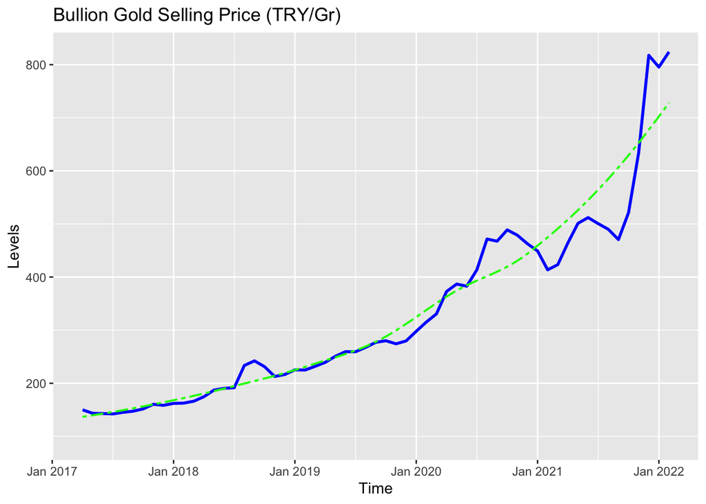

```r
ggplot(data=gold_usd_debt)+
  labs(title = "Bullion Gold Selling Price (TRY/Gr)", x = "Time", y = "Levels" ) +
  geom_line(group=1,size=1,color='blue', aes(x=Tarih,y=`TP MK KUL YTL`)) +
  geom_smooth(fill = NA, color="green",linetype = "twodash", size = 0.7, aes(x=Tarih,y=`TP MK KUL YTL`))
```

Histogram of Gold-TRY data to have a better understanding of the trend and change frequencies:

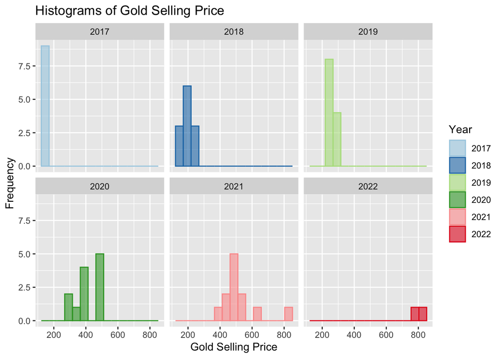

```r
ggplot(data = gold_usd_debt,aes(x = `TP MK KUL YTL` )) +
  geom_histogram(bins=15,alpha=0.6,aes(color=Year,fill=Year))+
  facet_wrap(facets= .~Year)+
  scale_color_brewer(palette = "Paired",aesthetics = c("color", "fill")) +
  labs(title = "Histograms of Gold Selling Price",
       x = "Gold Selling Price",
       y = "Frequency")
```

This histogram shows the frequencies of Gold Selling for each year and the increasing trend can be seen from here as well. We can conclude from this histograms that the steady state of Gold Selling Price was lost by the time passed since we have, in general, more price intervals and less corresponding frequency values from 2017 to 2021, which means the Gold Selling Price started to change more rapidly and the change is now more obvious than before.

Boxplot of Gold-TRY data to examine the trend and standard deviation of the values:

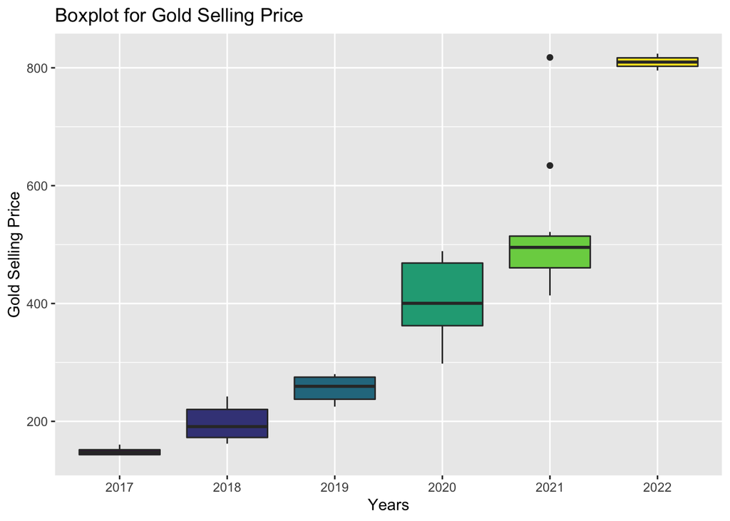

```r
ggplot(data = gold_usd_debt,aes(x=factor(Year),y=`TP MK KUL YTL`))+
  geom_boxplot(aes(fill=factor(Year)))+
  xlab("Years") + ylab("Gold Selling Price")+
  ggtitle("Boxplot for Gold Selling Price")+
  theme(legend.position = "none")
```

Search volume of “gram altın”:

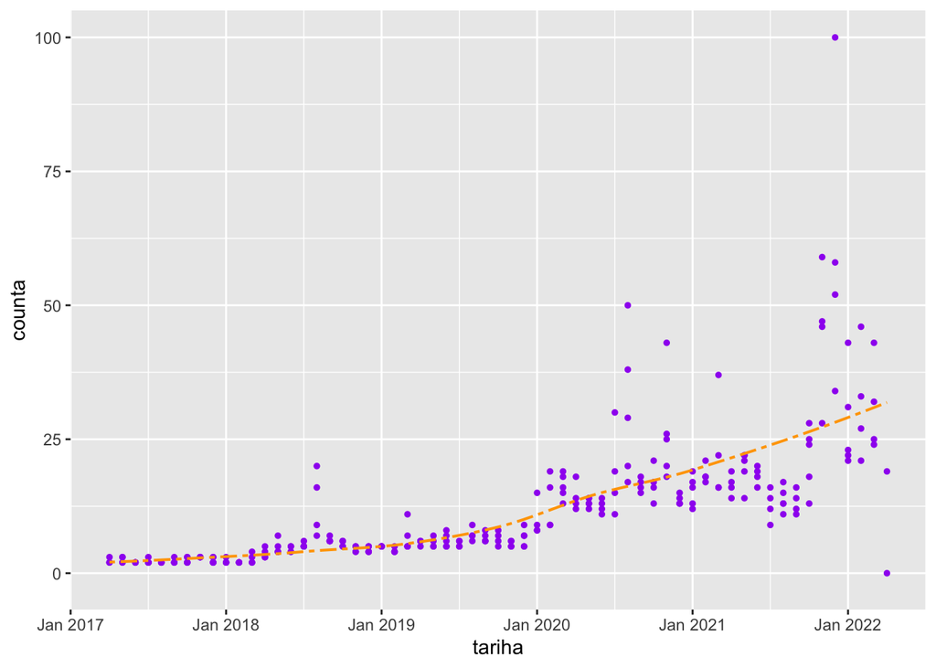

```r
gram_altin <- read_excel("/Users/ertugruluyar/Downloads/gram-altin.xlsx")
gram_altin$tariha <- as.yearmon(x = gram_altin$tariha)
ggplot(data = gram_altin)+
  geom_point(group =1,size = 1, color ='purple', aes(x=tariha, y= counta))+
  geom_smooth(fill = NA, color="orange",linetype = "twodash", size = 0.7, aes(x=tariha,y= counta))
```